# Applied Research: Paired-test and ANOVA

Carlos Utrilla Guerrero

6/08/2021

[figure not shown]

# WELCOME

Welcome to the workshop number 4: More about inferential stats with R.

**Learning outcomes:**

By the end of this assignment(s), you should be able to:

• Know-how to perform t.test for paired data

• Know-how to conduct and use One-way Anova test

## Paired t-test

[figure not shown]

As you already know, t-Tests are a great way of identifying if two group means are statistically different. This can be done by comparing a sample to the population (one-sample) or comparing two different samples (two-sample).T-tests are further broken down into two categories: unpaired t-tests and paired t-tests. This tutorial will focus on the latter.

### Import Dataset:

To illustrate the paired t-test, we will use the Student’s Sleep Data.

*Description* Data which show the effect of two soporific drugs (increase in hours of sleep compared to control) on 10 patients.

*Format* A data frame with 20 observations on 3 variables.

- [, 1] extra numeric increase in hours of sleep
- [, 2] group factor drug given
- [, 3] ID factor patient ID

Use the build-in `sleep` function to directly import into R the data set. Please, run the following R command:

```r
# import R data set 'sleep'
sleep <- sleep
sleep
```

```
##    extra group ID
## 1    0.7     1  1
## 2   -1.6     1  2
## 3   -0.2     1  3
## 4   -1.2     1  4
## 5   -0.1     1  5
## 6    3.4     1  6
## 7    3.7     1  7
## 8    0.8     1  8
## 9    0.0     1  9
## 10   2.0     1 10
## 11   1.9     2  1
## 12   0.8     2  2
## 13   1.1     2  3
## 14   0.1     2  4
## 15  -0.1     2  5
## 16   4.4     2  6
## 17   5.5     2  7
## 18   1.6     2  8
## 19   4.6     2  9
## 20   3.4     2 10
```

**Visualisation**

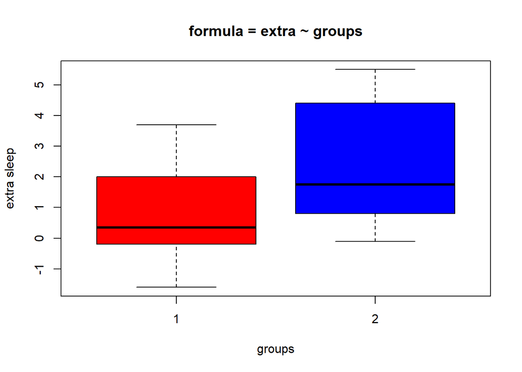

```r
boxplot(sleep$extra ~ sleep$group,
        col = c("red", "blue"),
        ylab = 'extra sleep',
        xlab = 'groups',
        main = 'formula = extra ~ groups')
```

### DEMO 1:

**Q2. Research question: Is there a statistically significant effect of the drug on sleep hours?**

```
##
##  Paired t-test
##
## data:  sleep$extra[sleep$group == 1] and sleep$extra[sleep$group == 2]
## t = -4.0621, df = 9, p-value = 0.002833
## alternative hypothesis: true difference in means is not equal to 0
## 95 percent confidence interval:
##  -2.4598858 -0.7001142
## sample estimates:
## mean of the differences
##                   -1.58
```

**Q3. What if we want to test the hypothesis that mean of group A is less than group B? Which parameter do you need to declare from the `t.test(0)` method?**

[output not shown]

## Analysis of the Variance (ANOVA)

### What is one-way ANOVA test?

The one-way analysis of variance (ANOVA), also known as one-factor ANOVA, is a statistical technique, commonly used to study differences between two or more group means. In one-way ANOVA, the data is organized into several groups base on one single grouping variable (also called factor variable). This section describes the basic principle of the one-way ANOVA test and provides practical anova test examples in R software.

### ANOVA test hypotheses:

[figure not shown]

- $Ho$ –> Null hypothesis: the means of the different groups are the same.
- $Ha$ –> Alternative hypothesis: At least one sample mean is not equal to the others.

*Note that, if you have only two groups, you can use t-test. In this case the F-test and the t-test are equivalent*.

#### General steps to conduct an ANOVA

Here are the 2 steps you should follow to conduct a standard ANOVA in R:

1. Create an ANOVA object using the `aov()` function. In the `aov()` function, specify the independent and dependent variable(s) with a formula with the format `y ~ x1` where `y` is the dependent variable, and x1, are one (more more) factor independent variables.
2. Create a summary ANOVA table by applying the `summary()` function to the ANOVA object you created in Step 1.

```r
# Step 2: Look at a summary of the aov object
summary(mod.aov)
```

[output not shown]

### Import dataset

Here, we’ll use the built-in R data set named PlantGrowth. It contains the weight of plants obtained under a control and two different treatment conditions.

```r
plants <- PlantGrowth # import dataset with R built function
# show the levels == categpries
levels(plants$group)
```

```
## [1] "ctrl" "trt1" "trt2"
```

### Check your data

```r
head(plants)
```

```
##   weight group
## 1   4.17  ctrl
## 2   5.58  ctrl
## 3   5.18  ctrl
## 4   6.11  ctrl
## 5   4.50  ctrl
## 6   4.61  ctrl
```

Note: In R terminology, the column “group” is called factor and the different categories (“ctr”, “trt1”, “trt2”) are named factor levels. The levels are ordered alphabetically.

```r
# Show the levels
levels(plants$group)
```

```
## [1] "ctrl" "trt1" "trt2"
```

### DEMO 2:

**Q2: We want to know if there is any significant difference between the average weights of plants in the 3 experimental conditions**

This work is licensed under the [CC BY-NC 4.0 Creative Commons License](http://creativecommons.org/licenses/by-nc/4.0/).